# Homework 2 Solution Key

Jyotishka Datta

2020-10-06

## Problem 1

### Problem 1.1

We can use inverse transformation idea here. Note that the CDF is $F(x) = 1 - \cos(x)$, and the inverse is $F^{-1}(u) = \cos^{-1}(1-u)$.

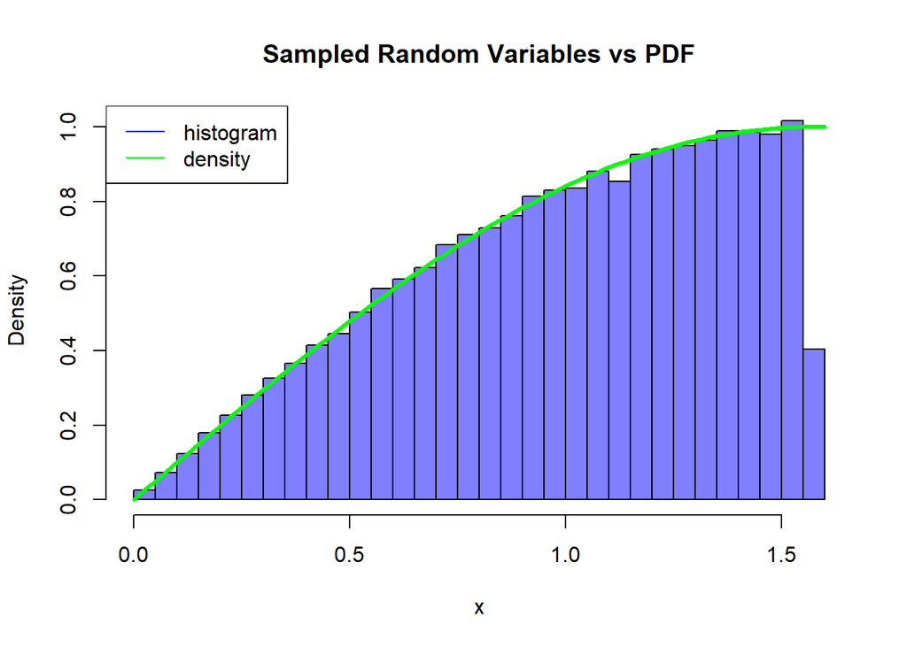

```r
set.seed(26)
x <- acos(runif(1e5,0,1))

hist(x, breaks = 50, freq = F,
     col = rgb(0,0,1,0.5),
     main = "Sampled Random Variables vs PDF")

# Actual PDF of the desired distribution
target <- function(x){sin(x)/
    integrate(function(x) sin(x),0, pi/2)$value}
# Adding the curve to the histogram of sampled random variables
curve(target,lwd=3,add=T, col = 'green')
legend("topleft",c("histogram","density"),col=c("blue","green"),lty = c(1,1))
```

### Problem 1.2

A second method could be rejection sampling. We can choose a uniform density as the envelope, and also calculate the efficiency easily.

```r
# Create the function rsin to generate the samples

rsin.ar <- function(n){
# Input: n = number of samples
# Output: n samples from p(x)=sin(x), 0<x<pi/2
#   uses accept/reject method with g(x)~Unif(0,pi/2)

  # vector to hold answer
  ans <- rep(0,n)

  # index
  i <- 1

  # hold j to keep track of efficiency
  j <- 0

  # while loop to generate answer
  while(i <= n){

    # generate X~g(x) and U~Unif(0,1)
    x <- runif(1,min=0,max=pi/2)
    u <- runif(1)

    # if x is good (u < p(x)/Mg(x)) keep it
    if(u <= sin(x)){
      ans[i] <- x
      i <- i + 1
    }else{
      # track bad samples
      j <- j + 1
    }
  }
  # print the proportion of good samples, should be 1/M = 2/pi = 0.6366
  print(paste0('Efficiency is ', n/(j+n)))

  # return the answer
  return(ans)
}

# Generate 1,000,000 samples
y <- rsin.ar(1e6)
```

```
## [1] "Efficiency is 0.636325803902204"
```

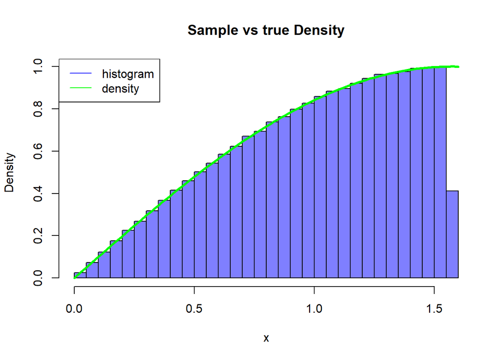

```r
hist(y, breaks=50, freq=FALSE,
     main="Sample vs true Density",col = rgb(0,0,1,0.5), xlab = "x")

# Actual PDF of the desired distribution
target <- function(x){sin(x)/
    integrate(function(x) sin(x),0, pi/2)$value}

# Adding the curve to the histogram of sampled random variables
curve(target,lwd=3,add=T, col = 'green')

legend("topleft",c("histogram","density"),col=c("blue","green"),lty = c(1,1))
```

## Problem 2

The density given here is:
$$f(x) = \lambda x^{-\lambda-1}$$

The CDF and inverse CDF would be:
$$F(x) = 1 - x^{-\lambda}, \; F^{-1}(u) = (1-u)^{-\frac{1}{\lambda}}.$$

This is in fact the Pareto density. See the wiki page: https://en.wikipedia.org/wiki/Pareto_distribution

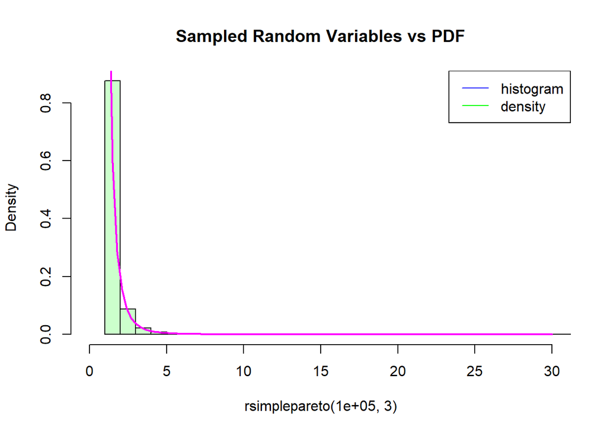

```r
rsimplepareto <- function(n, lambda = 3){
  u = runif(n)
  return((1/u^(1/lambda)))
}

hist(rsimplepareto(1e5, 3), breaks = 100, freq = F,
     col = rgb(0,1,0,0.2),
     main = "Sampled Random Variables vs PDF", xlim = c(0,30))

# Adding the curve to the histogram of sampled random variables
curve(3*x^(-4),lwd=2,add=T, col = 'magenta')
legend("topright",c("histogram","density"),col=c("blue","green"),lty = c(1,1))
```

### Problem 2.2

To estimate $E(X^{2.5})$ simply generate a large sample from the target density and calculate
$$\widehat{E(X^{2.5})} = \frac{1}{N}\sum_{i=1}^{N}x_i^{2.5}$$

where $x_i$’s are the samples from the target distribution.

```r
x = rsimplepareto(1e5, 3)
cat("Estimate of E(X^(2.5)) is ", mean(x^(2.5)))
```

```
## Estimate of E(X^(2.5)) is  5.999357
```

## Problem 3

This is exactly like the problem 1 we solved in the sampling lab but instead of $f(x) = \exp\{-x^6/10\}$ on $x \in (0, \infty)$, we have $f(x) = \exp\{-x^4/12\}$ but on the entire real line. Now, if we can get samples from $\exp\{-x^4/12\}$ on the positive half of real line, we can simply take random half of those samples, flip their signs and get samples from the density on the entire real line.

See the link: http://dattahub.github.io/stat5443/lab_ex_sampling_2020_solutions.html.

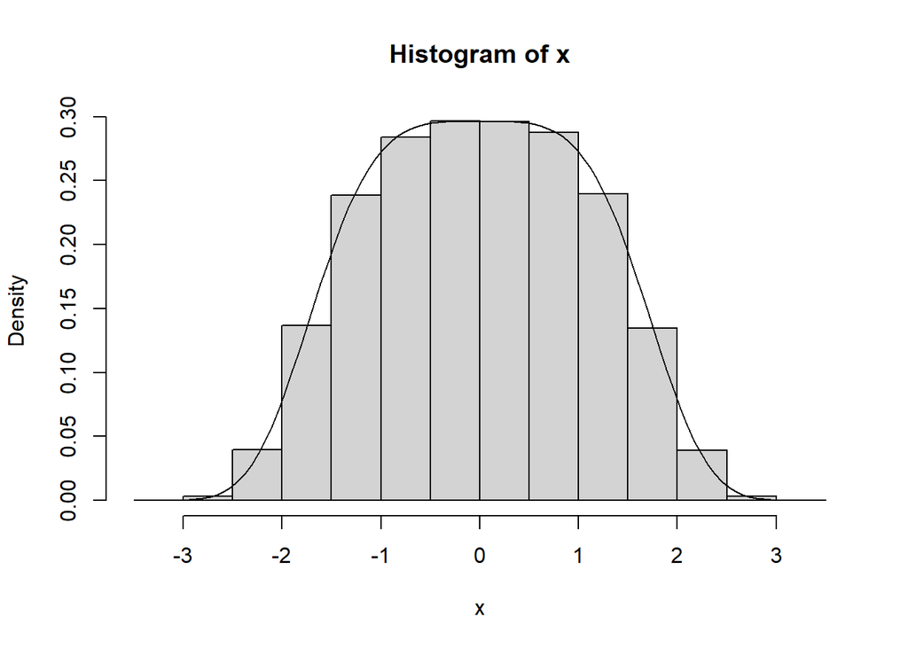

```r
#######################################################
# Use inverse CDF to sample from \propto exp(-x^4/12) #
#   this follows from work done in sampling lab 2     #
#######################################################

# parameters
lambda <- 1/12
alpha <- 1/4
n <- 1e5

# generate from y described in part 2
y <- rgamma(n,shape=alpha,rate=lambda)

# transform to x and convert some to negative
x <- y**alpha

# u will be 1 if runif <= 0.5 and 0 o.w.
u <- as.numeric(runif(n) <= 0.5)

# u will be -1 if runif <= 0.5 and 1 o.w.
u <- 1-2*u

# now x will be ~half positive and ~half negative
x <- x*u

# true density of x
dens <- function(x) exp(-lambda*x^(1/alpha))/
integrate(function(x) exp(-lambda*x^(1/alpha)),-Inf,Inf)$value

# plot of samples x
hist(x, freq=F)

# true density curve of x
curve(dens, add=T)
```